# Change-point estimation of protein requirements from IAAO data: analyses for the R1 revision

Author

Shuntaro Sato

Published

2026/10/20, 14:32

# 1 Setup

This document reproduces the analyses of the four published datasets for the revised manuscript (PONE-D-26-20307, R1). Changes from the submitted code (`analyses_4studies_2506.qmd` in the version of this repository at submission) are listed at the top of `functions.R`; in short, the bounds of the population change-point of Model 4 are now passed to Stan, and the scale of the prior for the SD of the random change-point is an argument. The simulation study is in `simulation_report.qmd`.

```r
source("functions.R")
library(patchwork)
library(gt)

rstan_options(auto_write = TRUE)
options(mc.cores = 4)

dir.create("output", showWarnings = FALSE)

ds <- load_ds("data/ds_4studies.rds")
data_by_study <- ds |>
  group_nest(manuscript) |>
  mutate(data = map(data, ~ mutate(.x, id = fct_drop(id))))

study_labels <- c(
  "a: Rafii, 2015"  = "(A) Rafii et al. (2015)",
  "b: Packer, 2017" = "(B) Packer et al. (2017)",
  "c: Mao, 2020"    = "(C) Mao et al. (2020)",
  "d: Wu, 2024"     = "(D) Wu et al. (2024)"
)

# Published EAR and upper value (upper limit of the 95% CI; recommended nutrient intake for Mao)
published <- tribble(
  ~manuscript,       ~pub_ear, ~pub_upper,
  "a: Rafii, 2015",  0.96,     1.29,
  "b: Packer, 2017", 1.20,     1.40,
  "c: Mao, 2020",    0.91,     1.17,
  "d: Wu, 2024",     0.94,     1.13
)

model_colors <- c("Model 2" = "#4269d0", "Model 3" = "#6cc5b0", "Model 4" = "#ff725c")
y_lab <- expression({}^{13} * CO[2])
x_lab <- "Protein intake (g/kg/day)"
x_scale <- scale_x_continuous(breaks = seq(0, 2.5, by = 0.5))
```

# 2 Data

```r
data_summary <- data_by_study |>
  mutate(summ = map(data, function(d) {
    per_id <- d |> group_by(id) |> summarise(k = n(), .groups = "drop")
    tibble(
      n_participants = n_distinct(d$id),
      n_obs = nrow(d),
      obs_per_participant = sprintf("%g (%d-%d)", median(per_id$k), min(per_id$k), max(per_id$k)),
      intake_range = sprintf("%.2f-%.2f", min(d$protein), max(d$protein)),
      n_intake_levels = n_distinct(d$protein)
    )
  })) |>
  select(manuscript, summ) |>
  unnest(summ)

write_csv(data_summary, "output/table_data_summary.csv")
gt(data_summary)
```

| manuscript | n_participants | n_obs | obs_per_participant | intake_range | n_intake_levels |
| --- | --- | --- | --- | --- | --- |
| a: Rafii, 2015 | 12 | 71 | 6 (2-10) | 0.20-2.00 | 23 |
| b: Packer, 2017 | 7 | 47 | 7 (4-10) | 0.20-2.60 | 47 |
| c: Mao, 2020 | 14 | 74 | 6 (3-6) | 0.30-1.80 | 6 |
| d: Wu, 2024 | 16 | 106 | 7 (5-7) | 0.10-1.80 | 7 |

# 3 Models 2 and 3

As in the submitted analysis: `lme()` with REML, and the 95% CI defined by the candidate change-points closest to the estimate at which the AIC exceeds its minimum by 4. The candidate change-points span 0 to 2.5 g/kg/day by 0.01 (submitted: 0.5 to 2.5), the same range as the bounds of the population change-point in Model 4; the results are identical with both ranges.

```r
mixed <- expand_grid(study = seq_len(nrow(data_by_study)), model = c("Model 2", "Model 3")) |>
  mutate(res = map2(study, model, function(s, m) {
    profile_mixed_cp(data_by_study$data[[s]], random_slope = (m == "Model 3"))
  })) |>
  mutate(manuscript = data_by_study$manuscript[study]) |>
  unnest(res)

mixed |>
  select(manuscript, model, cp, lower, upper) |>
  write_csv("output/table_models23.csv")

mixed |>
  select(manuscript, model, cp, lower, upper) |>
  gt(groupname_col = "manuscript") |>
  fmt_number(columns = c(cp, lower, upper), decimals = 2)
```

| model | cp | lower | upper |
| --- | --- | --- | --- |
| a: Rafii, 2015 |  |  |  |
| Model 2 | 1.32 | 1.07 | 1.52 |
| Model 3 | 1.36 | 1.09 | 1.53 |
| b: Packer, 2017 |  |  |  |
| Model 2 | 1.65 | 1.22 | 2.07 |
| Model 3 | 1.67 | 1.33 | 2.13 |
| c: Mao, 2020 |  |  |  |
| Model 2 | 0.90 | 0.78 | 1.02 |
| Model 3 | 0.90 | 0.78 | 1.00 |
| d: Wu, 2024 |  |  |  |
| Model 2 | 0.82 | 0.69 | 1.03 |
| Model 3 | 0.84 | 0.69 | 1.04 |

# 4 Model 4

Settings:

- **primary**: population change-point bounded to (0, 2.5) g/kg/day with a Normal(0, 1) prior on the logit scale; half-normal(0, 0.3) prior for the SD of the random change-point.
- **sd10**: as primary, with a half-normal(0, 1) prior for the SD of the random change-point (sensitivity analysis).
- **as_submitted**: as primary, but with bounds (0.5, 2.0); this reproduces the submitted HTML report (the bounds were not passed to Stan).

```r
sm <- stan_model("model4_random_cp.stan")

m4_settings <- tribble(
  ~setting,        ~prior_sd_cp, ~lower, ~upper,
  "primary",       0.3,          0,      2.5,
  "sd10",          1.0,          0,      2.5,
  "as_submitted",  0.3,          0.5,    2.0
)

m4 <- expand_grid(study = seq_len(nrow(data_by_study)), s = seq_len(nrow(m4_settings))) |>
  mutate(out = map2(study, s, function(study, s) {
    st <- m4_settings[s, ]
    d <- data_by_study$data[[study]]
    res <- run_model4(sm, d, prior_sd_cp = st$prior_sd_cp, lower = st$lower, upper = st$upper,
                      save_pred = (st$setting == "primary"))
    out <- list(
      pop = summarise_model4(res),
      ind = individual_model4(res),
      sd_cp_draws = rstan::extract(res$fit, pars = "u_sd")$u_sd[, 3],
      curves = if (st$setting == "primary") curves_model4(res) else NULL
    )
    rm(res); gc()
    out
  })) |>
  mutate(manuscript = data_by_study$manuscript[study], setting = m4_settings$setting[s])

m4_pop <- m4 |> mutate(pop = map(out, "pop")) |> select(manuscript, setting, pop) |> unnest(pop)
m4_ind <- m4 |> mutate(ind = map(out, "ind")) |> select(manuscript, setting, ind) |> unnest(ind)

write_csv(m4_pop, "output/table_model4_settings.csv")
write_csv(m4_ind, "output/table_model4_individual.csv")

m4_pop |>
  select(manuscript, setting, cp_median, cp_lower, cp_upper, sd_cp_median, sd_cp_lower, sd_cp_upper,
         max_rhat, min_ess_bulk, n_divergent, secs) |>
  gt(groupname_col = "manuscript") |>
  fmt_number(columns = c(cp_median, cp_lower, cp_upper, sd_cp_median, sd_cp_lower, sd_cp_upper), decimals = 3) |>
  fmt_number(columns = c(max_rhat), decimals = 3) |>
  fmt_number(columns = c(min_ess_bulk, secs), decimals = 0)
```

| setting | cp_median | cp_lower | cp_upper | sd_cp_median | sd_cp_lower | sd_cp_upper | max_rhat | min_ess_bulk | n_divergent | secs |
| --- | --- | --- | --- | --- | --- | --- | --- | --- | --- | --- |
| a: Rafii, 2015 |  |  |  |  |  |  |  |  |  |  |
| primary | 1.298 | 1.080 | 1.519 | 0.090 | 0.004 | 0.313 | 1.001 | 2,631 | 0 | 22 |
| sd10 | 1.298 | 1.077 | 1.536 | 0.104 | 0.005 | 0.381 | 1.002 | 2,568 | 0 | 8 |
| as_submitted | 1.294 | 1.080 | 1.506 | 0.090 | 0.004 | 0.307 | 1.001 | 3,086 | 0 | 8 |
| b: Packer, 2017 |  |  |  |  |  |  |  |  |  |  |
| primary | 1.586 | 1.212 | 2.025 | 0.255 | 0.021 | 0.570 | 1.001 | 3,421 | 0 | 16 |
| sd10 | 1.590 | 1.175 | 2.057 | 0.344 | 0.048 | 0.864 | 1.001 | 3,208 | 0 | 8 |
| as_submitted | 1.531 | 1.191 | 1.824 | 0.254 | 0.027 | 0.569 | 1.001 | 3,939 | 0 | 6 |
| c: Mao, 2020 |  |  |  |  |  |  |  |  |  |  |
| primary | 0.897 | 0.772 | 1.052 | 0.056 | 0.003 | 0.213 | 1.001 | 2,925 | 0 | 18 |
| sd10 | 0.901 | 0.773 | 1.060 | 0.057 | 0.003 | 0.232 | 1.002 | 2,785 | 0 | 6 |
| as_submitted | 0.905 | 0.780 | 1.065 | 0.056 | 0.002 | 0.215 | 1.001 | 2,970 | 0 | 5 |
| d: Wu, 2024 |  |  |  |  |  |  |  |  |  |  |
| primary | 0.866 | 0.710 | 1.055 | 0.103 | 0.006 | 0.269 | 1.003 | 2,194 | 0 | 22 |
| sd10 | 0.864 | 0.706 | 1.058 | 0.112 | 0.007 | 0.292 | 1.001 | 2,532 | 0 | 7 |
| as_submitted | 0.879 | 0.725 | 1.067 | 0.109 | 0.006 | 0.278 | 1.001 | 2,929 | 0 | 7 |

# 5 Random change-point model of Tang et al. (2014)

Only the change-point varies among participants; maximum likelihood with the exact likelihood (ML) and with the first-order approximation (FO) used by Mao et al. (2020). RDA = mean + 1.96 SD of the change-points. Published values: Mao et al. (2020) EAR 0.91 (95% CI 0.76-1.06), RNI 1.17; Wu et al. (2024) EAR 0.94 (95% CI 0.75-1.13), RNI (EAR + 1.96 SD) 1.36.

```r
tang <- expand_grid(study = seq_len(nrow(data_by_study)), approx = c("ML", "FO")) |>
  mutate(res = map2(study, approx, function(s, a) fit_tang(data_by_study$data[[s]], a, individual = FALSE)$pop),
         manuscript = data_by_study$manuscript[study]) |>
  select(manuscript, approx, res) |>
  unnest(res)
write_csv(tang, "output/table_tang_published_data.csv")
tang |>
  select(manuscript, approx, est, lower, upper, tau, rda, rda_lower, rda_upper) |>
  gt(groupname_col = "manuscript") |>
  fmt_number(columns = -c(manuscript, approx), decimals = 2)
```

| approx | est | lower | upper | tau | rda | rda_lower | rda_upper |
| --- | --- | --- | --- | --- | --- | --- | --- |
| a: Rafii, 2015 |  |  |  |  |  |  |  |
| ML | 1.24 | 1.01 | 1.48 | 0.14 | 1.52 | 1.22 | 1.83 |
| FO | 1.29 | 1.09 | 1.49 | 0.14 | 1.56 | 1.25 | 1.86 |
| b: Packer, 2017 |  |  |  |  |  |  |  |
| ML | 1.66 | 1.22 | 2.10 | 0.35 | 2.35 | 1.64 | 3.05 |
| FO | 1.42 | 1.06 | 1.77 | 0.29 | 1.98 | 1.37 | 2.59 |
| c: Mao, 2020 |  |  |  |  |  |  |  |
| ML | 0.93 | 0.73 | 1.14 | 0.11 | 1.15 | 0.78 | 1.52 |
| FO | 0.90 | 0.74 | 1.07 | 0.14 | 1.17 | 0.87 | 1.48 |
| d: Wu, 2024 |  |  |  |  |  |  |  |
| ML | 1.05 | 0.75 | 1.35 | 0.28 | 1.59 | 1.08 | 2.11 |
| FO | 0.91 | 0.73 | 1.09 | 0.22 | 1.34 | 1.01 | 1.67 |

# 6 Table 2 (revised)

Point estimates with the upper limits of the 95% intervals (Models 2 and 3: AIC-based CI; Model 4: posterior median and 95% credible interval, primary setting). The full intervals are written to `output/table2_full.csv`.

```r
fmt_upper <- function(est, upper) sprintf("%.2f (%.2f)", est, upper)
table2 <- published |>
  transmute(manuscript, Published = fmt_upper(pub_ear, pub_upper)) |>
  left_join(
    mixed |> transmute(manuscript, model, value = fmt_upper(cp, upper)) |>
      pivot_wider(names_from = model, values_from = value),
    by = "manuscript"
  ) |>
  left_join(
    m4_pop |> filter(setting == "primary") |>
      transmute(manuscript, `Model 4` = fmt_upper(cp_median, cp_upper)),
    by = "manuscript"
  )
write_csv(table2, "output/table2_revised.csv")
gt(table2)
```

| manuscript | Published | Model 2 | Model 3 | Model 4 |
| --- | --- | --- | --- | --- |
| a: Rafii, 2015 | 0.96 (1.29) | 1.32 (1.52) | 1.36 (1.53) | 1.30 (1.52) |
| b: Packer, 2017 | 1.20 (1.40) | 1.65 (2.07) | 1.67 (2.13) | 1.59 (2.02) |
| c: Mao, 2020 | 0.91 (1.17) | 0.90 (1.02) | 0.90 (1.00) | 0.90 (1.05) |
| d: Wu, 2024 | 0.94 (1.13) | 0.82 (1.03) | 0.84 (1.04) | 0.87 (1.05) |

```r
table2_full <- bind_rows(
  mixed |> transmute(manuscript, model, est = cp, lower, upper),
  m4_pop |> filter(setting == "primary") |>
    transmute(manuscript, model = "Model 4", est = cp_median, lower = cp_lower, upper = cp_upper)
)
write_csv(table2_full, "output/table2_full.csv")

# Model 4: submitted Table 2, submitted HTML report (as_submitted), and revised analysis (primary);
# posterior means, as in the submitted report
m4_pop |>
  filter(setting %in% c("as_submitted", "primary")) |>
  transmute(manuscript, setting, value = fmt_upper(cp_mean, cp_upper)) |>
  pivot_wider(names_from = setting, values_from = value) |>
  left_join(tibble(manuscript = published$manuscript,
                   submitted_table2 = c("1.31 (1.58)", "1.59 (1.96)", "0.90 (1.05)", "0.86 (1.05)")),
            by = "manuscript") |>
  relocate(submitted_table2, .after = manuscript) |>
  gt()
```

| manuscript | submitted_table2 | primary | as_submitted |
| --- | --- | --- | --- |
| a: Rafii, 2015 | 1.31 (1.58) | 1.30 (1.52) | 1.29 (1.51) |
| b: Packer, 2017 | 1.59 (1.96) | 1.59 (2.02) | 1.53 (1.82) |
| c: Mao, 2020 | 0.90 (1.05) | 0.90 (1.05) | 0.91 (1.06) |
| d: Wu, 2024 | 0.86 (1.05) | 0.87 (1.05) | 0.88 (1.07) |

# 7 Sensitivity of Model 4 to the prior for the SD of the random change-point

```r
ind_change <- m4_ind |>
  filter(setting %in% c("primary", "sd10")) |>
  select(manuscript, setting, id, cp_median) |>
  pivot_wider(names_from = setting, values_from = cp_median) |>
  group_by(manuscript) |>
  summarise(max_abs_change = max(abs(sd10 - primary)), .groups = "drop")

sens <- m4_pop |>
  filter(setting %in% c("primary", "sd10")) |>
  mutate(prior = recode(setting, primary = "Half-normal(0, 0.3)", sd10 = "Half-normal(0, 1)")) |>
  select(manuscript, prior, cp_median, cp_lower, cp_upper, sd_cp_median, sd_cp_lower, sd_cp_upper,
         max_rhat, min_ess_bulk, n_divergent) |>
  left_join(ind_change, by = "manuscript") |>
  mutate(max_abs_change = if_else(prior == "Half-normal(0, 0.3)", NA_real_, max_abs_change))
write_csv(sens, "output/table_sensitivity.csv")
gt(sens, groupname_col = "manuscript") |>
  fmt_number(columns = c(cp_median, cp_lower, cp_upper, sd_cp_median, sd_cp_lower, sd_cp_upper,
                         max_rhat, max_abs_change), decimals = 3) |>
  fmt_number(columns = min_ess_bulk, decimals = 0)
```

| prior | cp_median | cp_lower | cp_upper | sd_cp_median | sd_cp_lower | sd_cp_upper | max_rhat | min_ess_bulk | n_divergent | max_abs_change |
| --- | --- | --- | --- | --- | --- | --- | --- | --- | --- | --- |
| a: Rafii, 2015 |  |  |  |  |  |  |  |  |  |  |
| Half-normal(0, 0.3) | 1.298 | 1.080 | 1.519 | 0.090 | 0.004 | 0.313 | 1.001 | 2,631 | 0 | NA |
| Half-normal(0, 1) | 1.298 | 1.077 | 1.536 | 0.104 | 0.005 | 0.381 | 1.002 | 2,568 | 0 | 0.012 |
| b: Packer, 2017 |  |  |  |  |  |  |  |  |  |  |
| Half-normal(0, 0.3) | 1.586 | 1.212 | 2.025 | 0.255 | 0.021 | 0.570 | 1.001 | 3,421 | 0 | NA |
| Half-normal(0, 1) | 1.590 | 1.175 | 2.057 | 0.344 | 0.048 | 0.864 | 1.001 | 3,208 | 0 | 0.083 |
| c: Mao, 2020 |  |  |  |  |  |  |  |  |  |  |
| Half-normal(0, 0.3) | 0.897 | 0.772 | 1.052 | 0.056 | 0.003 | 0.213 | 1.001 | 2,925 | 0 | NA |
| Half-normal(0, 1) | 0.901 | 0.773 | 1.060 | 0.057 | 0.003 | 0.232 | 1.002 | 2,785 | 0 | 0.005 |
| d: Wu, 2024 |  |  |  |  |  |  |  |  |  |  |
| Half-normal(0, 0.3) | 0.866 | 0.710 | 1.055 | 0.103 | 0.006 | 0.269 | 1.003 | 2,194 | 0 | NA |
| Half-normal(0, 1) | 0.864 | 0.706 | 1.058 | 0.112 | 0.007 | 0.292 | 1.001 | 2,532 | 0 | 0.013 |

```r
# Spread of the participant-specific change-points relative to their uncertainty (primary)
m4_ind |> filter(setting == "primary") |>
  group_by(manuscript) |>
  summarise(range_of_medians = sprintf("%.2f-%.2f", min(cp_median), max(cp_median)),
            mean_ci_width = mean(cp_upper - cp_lower), .groups = "drop") |>
  gt() |> fmt_number(columns = mean_ci_width, decimals = 2)
```

| manuscript | range_of_medians | mean_ci_width |
| --- | --- | --- |
| a: Rafii, 2015 | 1.25-1.35 | 0.60 |
| b: Packer, 2017 | 1.34-1.84 | 1.00 |
| c: Mao, 2020 | 0.88-0.91 | 0.40 |
| d: Wu, 2024 | 0.79-0.98 | 0.52 |

# 8 Figures

The figures of the manuscript are saved in `figures/`.

## 8.1 Fig 3 (Fig 2 at submission): population-level fits

All participants are shown, with a different point shape for each participant within a study (16 shapes). The submitted Fig 2 used the default shape palette, which has only six shapes, so the data of participants beyond the sixth were not drawn. The size (7 x 6 in) and font sizes are those of the submitted Fig 2. The Tang model (first-order approximation) is drawn at its population change-point, like the other models. The data for the figure are written to `figures/`, and the figure is drawn by `figures/make_fig3_actual_data.R`, which can also be run on its own to adjust the figure.

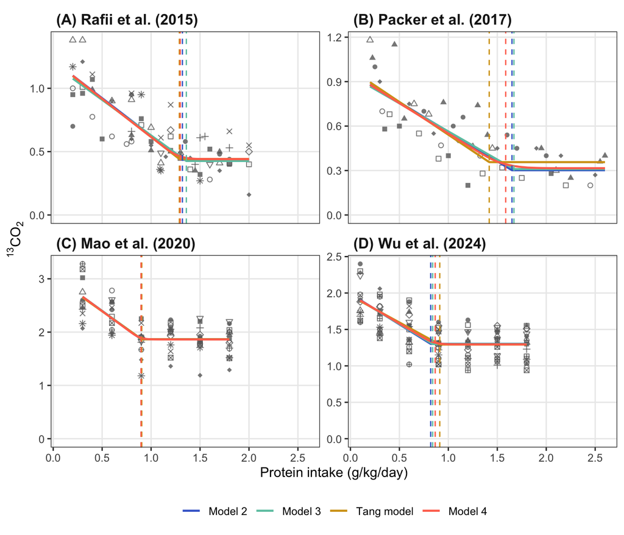

```r
fig2_models <- c("Model 2", "Model 3", "Tang model", "Model 4")
model_colors <- c(model_colors, "Tang model" = "#d4a017")

pop_curves <- map_dfr(seq_len(nrow(data_by_study)), function(s) {
  d <- data_by_study$data[[s]]
  ms <- data_by_study$manuscript[s]
  m2 <- mixed |> filter(manuscript == ms, model == "Model 2")
  m3 <- mixed |> filter(manuscript == ms, model == "Model 3")
  p2 <- predict_mixed(fit_mixed_at(d, m2$cp, FALSE), d, m2$cp) |> distinct(protein, pred_fixed)
  p3 <- predict_mixed(fit_mixed_at(d, m3$cp, TRUE), d, m3$cp) |> distinct(protein, pred_fixed)
  p4 <- m4 |> filter(manuscript == ms, setting == "primary") |> pull(out) |> pluck(1, "curves", "population")
  tg <- tang |> filter(manuscript == ms, approx == "FO")
  xs <- seq(min(d$protein), max(d$protein), by = 0.01)
  bind_rows(
    tibble(model = "Model 2", protein = p2$protein, fit = p2$pred_fixed),
    tibble(model = "Model 3", protein = p3$protein, fit = p3$pred_fixed),
    tibble(model = "Tang model", protein = xs, fit = tg$b0 + tg$b1 * pmin(xs - tg$est, 0)),
    tibble(model = "Model 4", protein = p4$protein, fit = p4$fit)
  ) |> mutate(manuscript = ms)
}) |>
  mutate(model = factor(model, levels = fig2_models))

cps <- bind_rows(
  mixed |> transmute(manuscript, model, cp, lower, upper),
  tang |> filter(approx == "FO") |> transmute(manuscript, model = "Tang model", cp = est, lower, upper),
  m4_pop |> filter(setting == "primary") |>
    transmute(manuscript, model = "Model 4", cp = cp_median, lower = cp_lower, upper = cp_upper)
) |>
  mutate(model = factor(model, levels = fig2_models))

# Input of figures/make_fig3_actual_data.R, which draws and saves the figure
dir.create("figures", showWarnings = FALSE)
write_csv(ds |> transmute(manuscript, id = as.character(id), protein, outcome), "figures/fig3_observed.csv")
write_csv(pop_curves |> select(manuscript, model, protein, fit), "figures/fig3_curves.csv")
write_csv(cps |> select(manuscript, model, cp, lower, upper), "figures/fig3_changepoints.csv")
fig3 <- local({
  e <- new.env()
  source("figures/make_fig3_actual_data.R", chdir = TRUE, local = e)
  e$fig
})
fig3
```

## 8.2 S1 Fig: participant-level fits

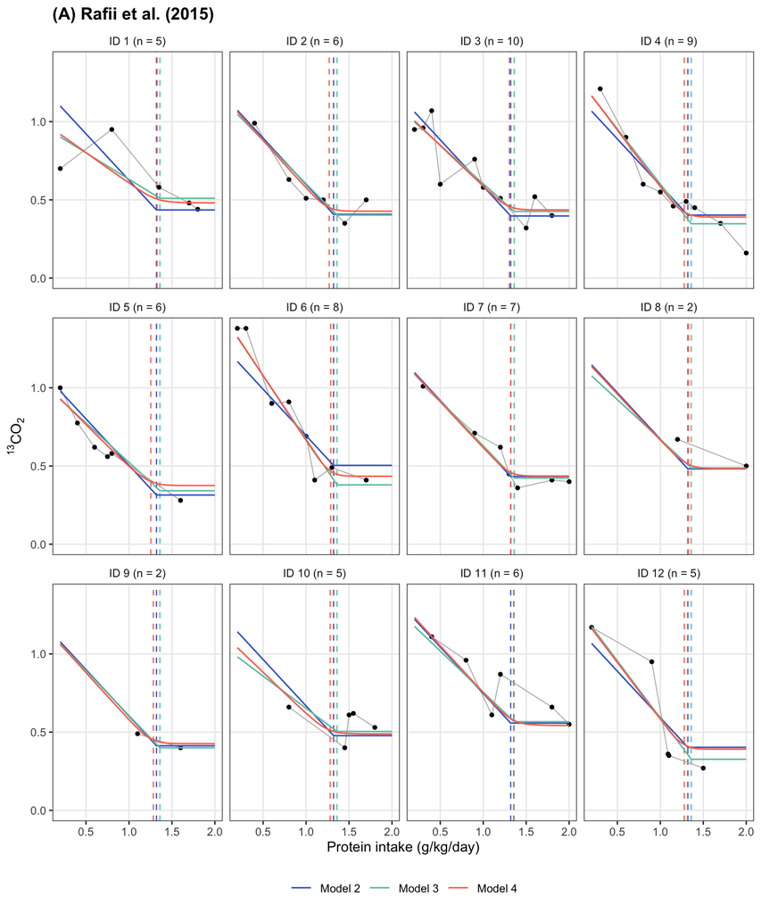

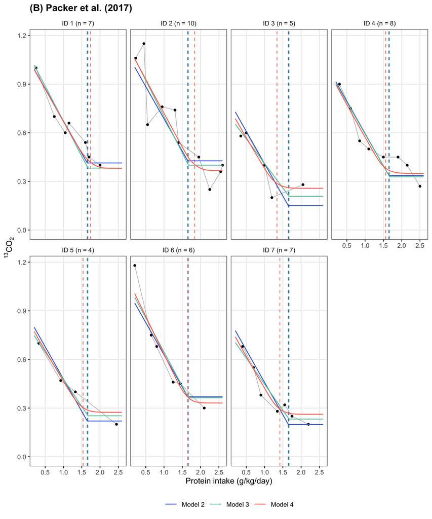

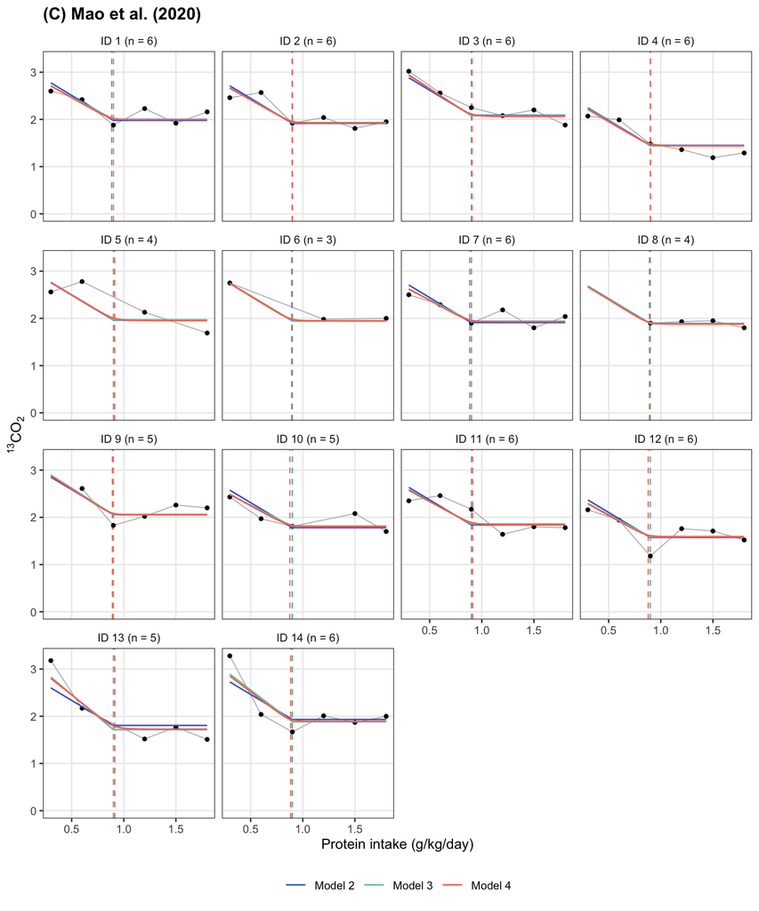

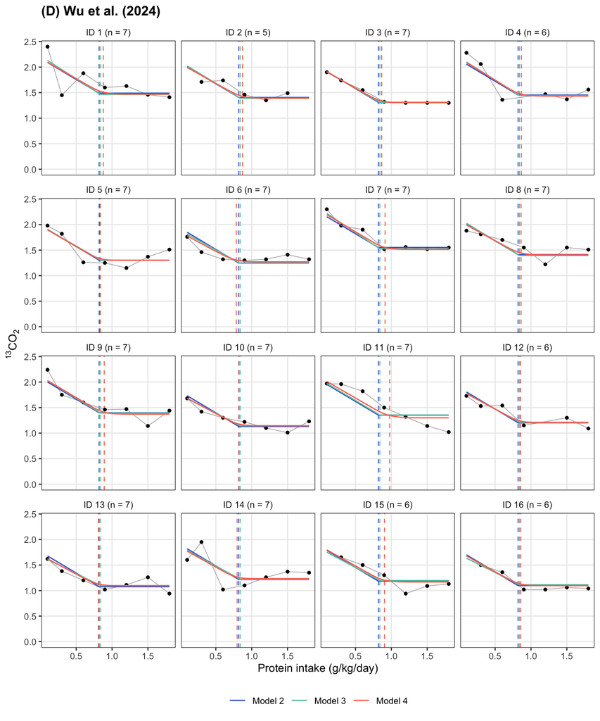

```r
s1_plots <- map(seq_len(nrow(data_by_study)), function(s) {
  d <- data_by_study$data[[s]]
  ms <- data_by_study$manuscript[s]
  m2 <- mixed |> filter(manuscript == ms, model == "Model 2")
  m3 <- mixed |> filter(manuscript == ms, model == "Model 3")
  p2 <- predict_mixed(fit_mixed_at(d, m2$cp, FALSE), d, m2$cp)
  p3 <- predict_mixed(fit_mixed_at(d, m3$cp, TRUE), d, m3$cp)
  o4 <- m4 |> filter(manuscript == ms, setting == "primary") |> pull(out) |> pluck(1)
  ind_curves <- bind_rows(
    tibble(model = "Model 2", id = as.character(p2$id), protein = p2$protein, fit = p2$pred_ind),
    tibble(model = "Model 3", id = as.character(p3$id), protein = p3$protein, fit = p3$pred_ind),
    o4$curves$individual |> mutate(model = "Model 4")
  )
  ind_cp <- o4$ind
  id_levels <- as.character(sort(as.integer(ind_cp$id)))
  lab <- ind_cp |> transmute(id, strip = sprintf("ID %s (n = %d)", id, n_obs))
  strip_map <- setNames(lab$strip, lab$id)
  dd <- d |> mutate(id = factor(as.character(id), levels = id_levels))
  ind_cp <- ind_cp |> mutate(id = factor(id, levels = id_levels))
  ind_curves <- ind_curves |> mutate(id = factor(id, levels = id_levels))
  common_cp <- tibble(model = c("Model 2", "Model 3"), cp = c(m2$cp, m3$cp))
  ggplot() +
    geom_vline(data = common_cp, aes(xintercept = cp, colour = model), linetype = "dashed", linewidth = 0.4,
               show.legend = FALSE) +
    geom_vline(data = ind_cp, aes(xintercept = cp_median), colour = model_colors["Model 4"],
               linetype = "dashed", linewidth = 0.4) +
    geom_line(data = dd, aes(protein, outcome), colour = "grey70", linewidth = 0.3) +
    geom_point(data = dd, aes(protein, outcome), size = 1) +
    geom_line(data = ind_curves, aes(protein, fit, colour = model), linewidth = 0.5) +
    scale_colour_manual(values = model_colors, name = NULL) +
    x_scale +
    facet_wrap(~ id, ncol = 4, labeller = as_labeller(strip_map)) +
    expand_limits(y = 0) +
    labs(title = study_labels[[ms]], x = x_lab, y = y_lab) +
    theme_bw(base_size = 10, base_family = "Arial") +
    theme(panel.grid.minor = element_blank(), legend.position = "bottom",
          strip.background = element_blank(), plot.title = element_text(size = 12, face = "bold"))
})
walk(s1_plots, print)
```

```r
# S1 Fig as one PDF for A4 printing: one study per A4 portrait page, panels of the same size on
# every page (4 columns, up to 4 rows), placed at the top of the page with 15 mm margins
write_a4_pdf <- function(plots, file, panel_w = 1.55, panel_h = 1.4, margin = 0.6) {
  grDevices::cairo_pdf(file, width = 8.27, height = 11.69, onefile = TRUE)
  on.exit(grDevices::dev.off())
  for (p in plots) {
    grid::grid.newpage()
    g <- ggplotGrob(p)
    g$widths[grid::unitType(g$widths) == "null"] <- unit(panel_w, "in")
    g$heights[grid::unitType(g$heights) == "null"] <- unit(panel_h, "in")
    w <- grid::convertWidth(sum(g$widths), "in", valueOnly = TRUE)
    h <- grid::convertHeight(sum(g$heights), "in", valueOnly = TRUE)
    stopifnot(w <= 8.27 - 2 * margin, h <= 11.69 - 2 * margin)
    grid::pushViewport(grid::viewport(y = unit(1, "npc") - unit(margin, "in"), width = unit(w, "in"),
                                      height = unit(h, "in"), just = c("centre", "top")))
    grid::grid.draw(g)
    grid::popViewport()
  }
}
write_a4_pdf(s1_plots, "figures/S1_Fig.pdf")
```